# [SAD] Projekt 1 - Dokumentacja

Marciniewicz Mateusz, Ostoja-Lniski Robert

2021-04-22

## Przygotowanie narzędzi i danych

W rozwiązaniu projektu korzystaliśmy z następujących bilbiotek

```r
library(dplyr)
library(tibble)
library(ggplot2)
```

# Zadanie 1

Zadanie 1 polegało na porównaniu notować spółek Orange Polska S.A. PEKO S.A.

```r
orange.df <- read.csv("./ORANGEPL.mst")
pekao.df <- read.csv("./PEKAO.mst")
```

## 1.a

W celu łatwiejszego przetwarzania danych oraz wizualizacji wyników zaimplementowaliśmy funkcje pomocnicze poniżej. Po preprocessingu, na podstawie danych generujemy wykresy.

```r
prepare_data <- function(df) {
  names(df) <- c('ticker', 'date', 'open', 'high', 'low', 'close', 'vol')

  df %>%
    filter(between(date, 20190700, 20191231)) %>%
    mutate(
      date = as.Date.character(date, format = "%Y%m%d"),
      delta = 100 * (close - lag(close)) / lag(close)
    ) %>%
    filter(row_number() != 1)
}

draw_delta <- function(df) {
  ggplot(df, aes(date, delta)) +
    geom_path(colour = "blue") +
    theme_bw() +
    labs(
      title = paste("[2019] Procentowe zmiany cen zamknięcia spółki", df[1, 1]),
      x = "Data",
      y = "Zmiany cen zamknięcia [%]"
    )
}
```

### Wykresy przedstawiające procentowe zmiany cen akcji

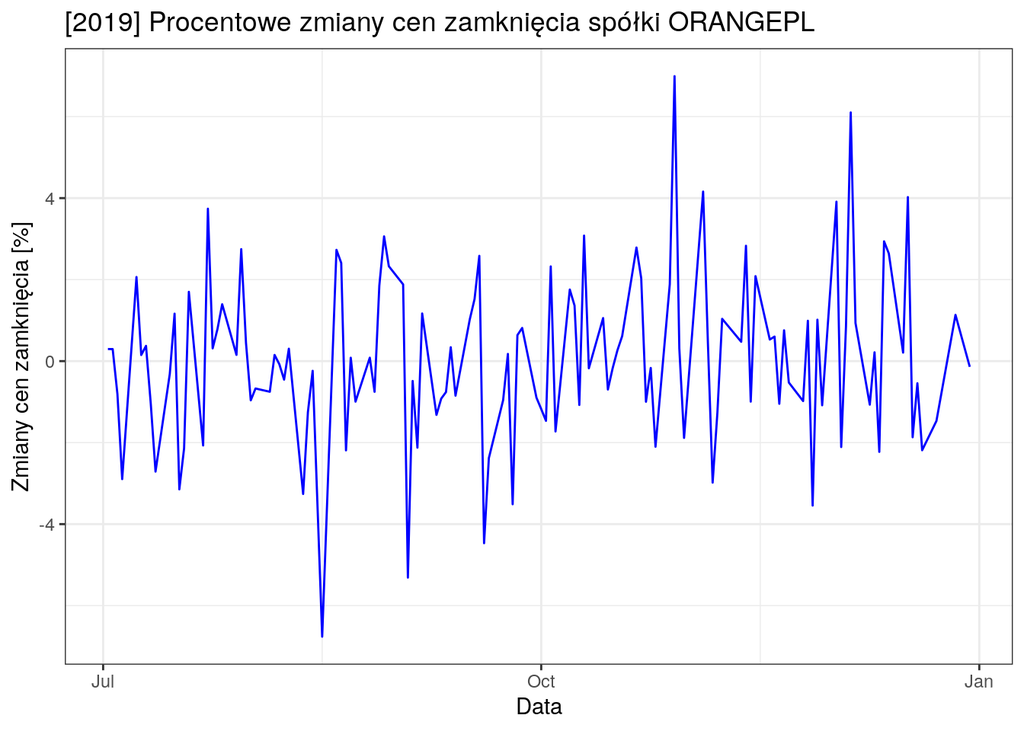

```r
orange.df <- prepare_data(orange.df)
pekao.df <- prepare_data(pekao.df)
draw_delta(orange.df)
```

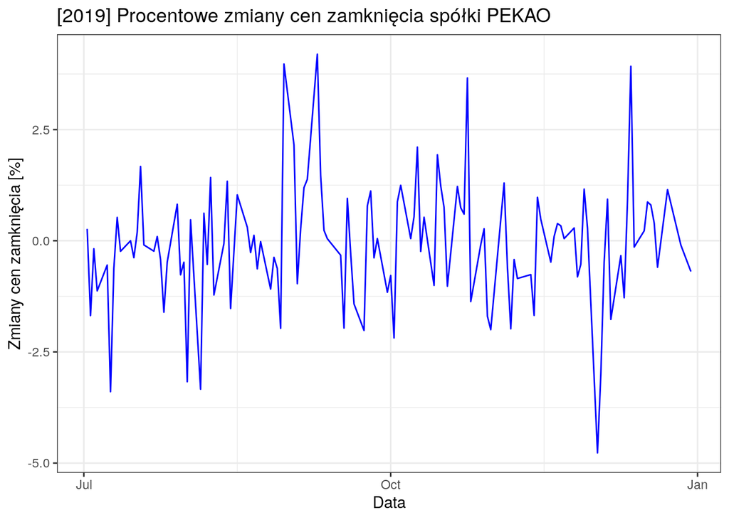

```r
draw_delta(pekao.df)
```

## 1.b

Rysowanie histogramu oraz wykresów pudełkowych odbywa się, analogicznie jak w punkcje 1.a, przy użyciu funkcji opakowujących narzędzia z pakietu ggplot.

```r
draw_histogram <- function(df) {
  ggplot(df, aes(delta)) +
    theme_bw() +
    geom_histogram(aes(y = ..density..), colour = "white", fill = "blue", binwidth=1) +
    labs(
      title = paste("[2019] Histogram procentowych zmian zamknięcia spółki", df[1, 1]),
      x = "Zmiany cen zamknięcia [%]",
      y = "Częstość występowania"
    )
}

draw_boxplot <- function(df) {
  ggplot(df, aes(ticker, delta)) +
    theme_bw() +
    geom_boxplot() +
    labs(
      title = paste("[2019] Boxplot procentowych zmian zamknięcia spółki", df[1, 1]),
      x = "",
      y = "Zmiany cen zamknięcia [%]"
    )
}
```

### Wykresy przedstawiające histogramy oraz wykresy pudełkowe

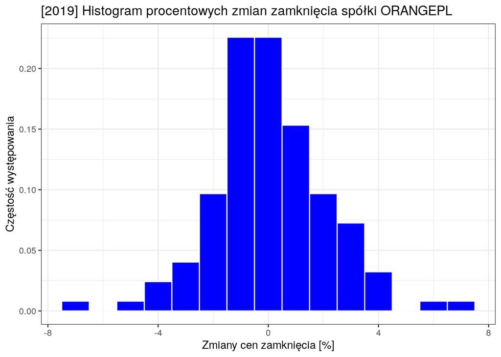

```r
draw_histogram(orange.df)
```

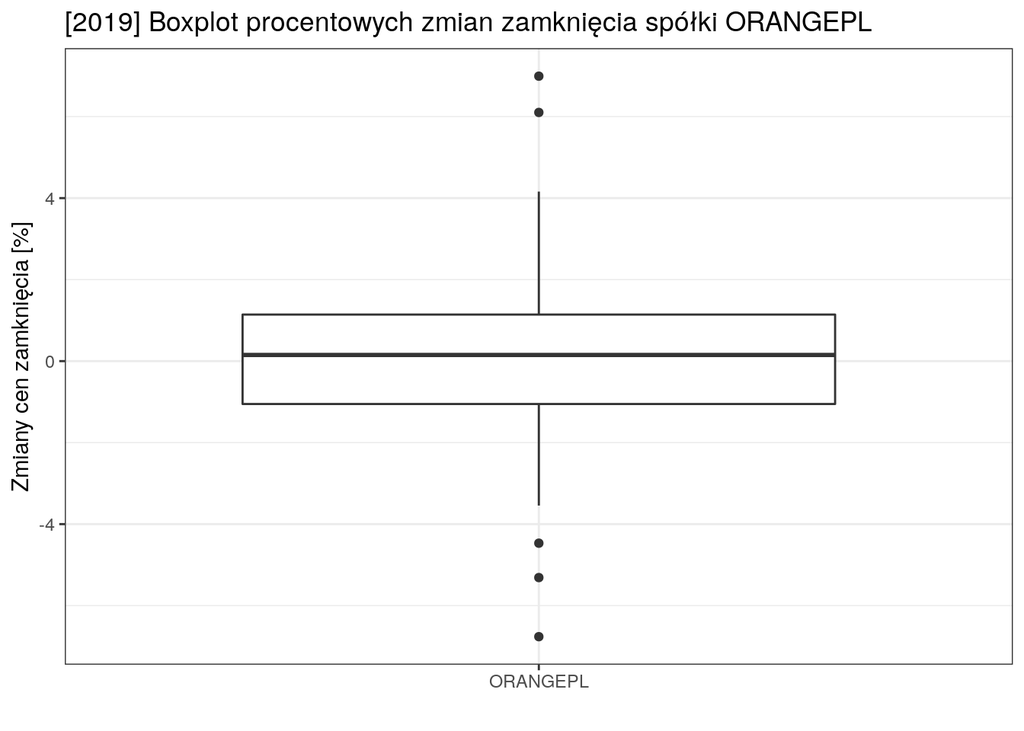

```r
draw_boxplot(orange.df)
```

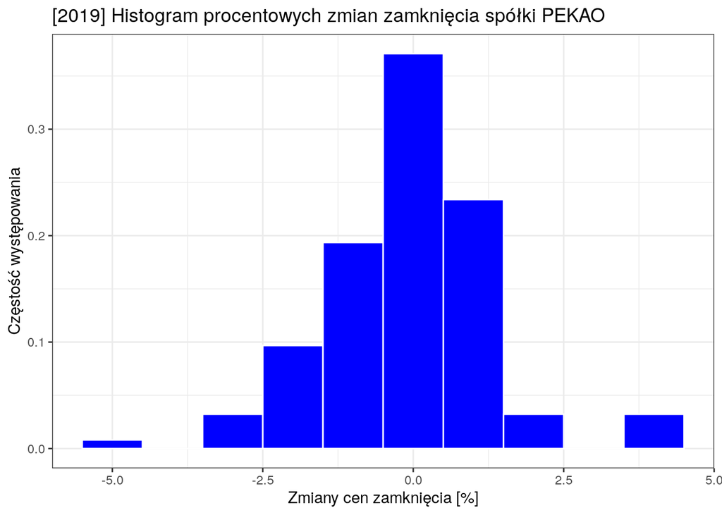

```r
draw_histogram(pekao.df)
```

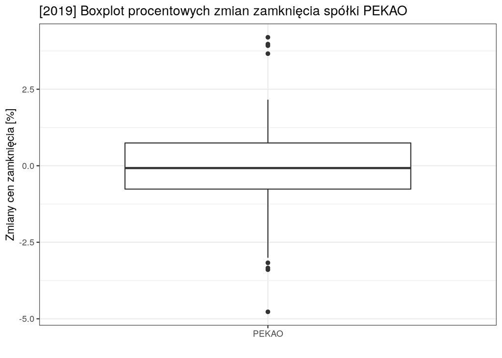

```r
draw_boxplot(pekao.df)
```

## 1.c

Estymacja parametrów odbywa się korzystając z funkcji wbudowanych. Niezbędnymi parametrami są średnia i odchylenie standardowe

```r
orange.mean <- mean(orange.df$delta)
orange.sd <- sd(orange.df$delta)
pekao.mean <- mean(pekao.df$delta)
pekao.sd <- sd(pekao.df$delta)
```

## 1.d

Krzywe rozkładu normalnego jednoznacznie pokrywają się z wykresem słupkowym. Zdarzają się niewielkie różnice między wykresami, ale nie są na tyle znaczące, żeby sugerowały niepoprawne zamodelowanie. Prawdopodobnie przy zwiększeniu liczności zbioru danych (uzyskaniu lepszego estymatora) wykresy byłyby jeszcze bardziej zbliżone.

### Wykresy porównujące modelowy rozkład, a faktyczne dane.

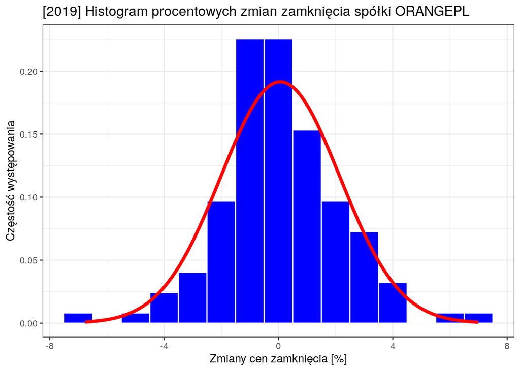

```r
draw_histogram(orange.df) +
  stat_function(fun = dnorm, args = list(mean = orange.mean, sd = orange.sd), colour = "red", size = 1.5)
```

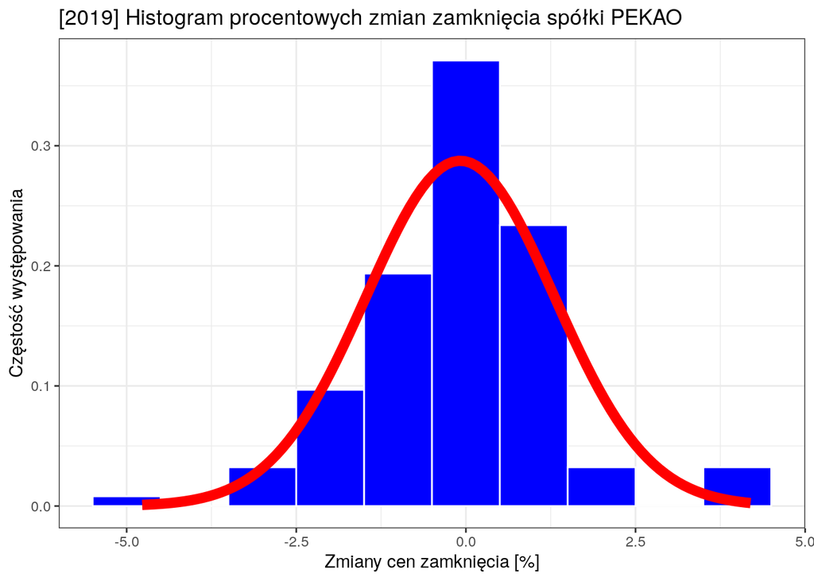

```r
draw_histogram(pekao.df) +
  stat_function(fun = dnorm, args = list(mean = pekao.mean, sd = pekao.sd), colour = "red", size = 3)
```

# Zadanie 2

Wycztanie danych zawierających transakcje z października 2019 roku wraz z informacjami o cenie i wolumenie.

```r
orange.df <- arrange(read.csv("./ORANGEPL.csv"), date)
```

## 2.a

Wyznaczeniu ceny z każdej fazy notowań odpowiada oddzielna funkcja. Open_phase wyznacza wolumen transakcji z czasem 9:00 oraz ceną taką jak pierwsza transakcja tego dnia. Continuous_phase wyznacza wolumen transakcji z przedziału 9:00 do 16:51, ale bez transakcji z otwarcia. Close_phase wyznacza wolumen w dogrywce, czyli po 16:59.

Następnie funkcja phase combined łaczy informacje uzyskane przez poprzednie funkcje, aby określić rozkład wolumenu między fazy dnia notowań.

```r
open_phase <- orange.df %>%
  filter(time == 090000) %>%
  group_by(date, time, price) %>%
  summarise(volume = sum(volume)) %>%
  filter(row_number() == 1)

continuous_phase <- orange.df %>%
  filter(between(time, 090000, 165100)) %>%
  group_by(date) %>%
  summarise(volume = sum(volume)) %>%
  mutate(volume = volume - open_phase$volume)

close_phase <- orange.df %>%
  filter(time > 165900) %>%
  group_by(date) %>%
  summarise(volume = sum(volume))

phases_combined <- open_phase %>%
  ungroup() %>%
  rename(open_volume = volume) %>%
  mutate(date = as.Date.character(date, format = "%y%m%d")) %>%
  add_column(continuous_volume = continuous_phase$volume) %>%
  add_column(close_volume = close_phase$volume) %>%
  select(-time, -price)
```

### Wykres przedstawiający rozkłąd wolumenu między fazami (otwarcie, notowania ciągłe, dogrywka)

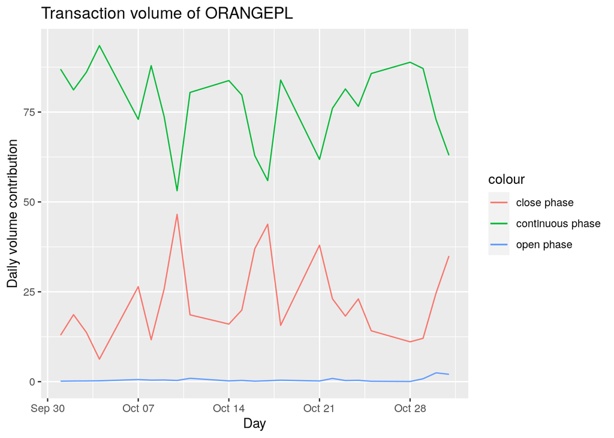

```r
ggplot(phases_combined, aes(date)) +
  geom_line(aes(
    y = 100 * open_volume / (open_volume + continuous_volume + close_volume),
    color = "open phase")) +
  geom_line(aes(
    y = 100 * continuous_volume / (open_volume + continuous_volume + close_volume),
    color = "continuous phase")) +
  geom_line(aes(
    y = 100 * close_volume / (open_volume + continuous_volume + close_volume),
    color = "close phase")) +
  labs(
    title = "Transaction volume of ORANGEPL",
    x = "Day",
    y = "Daily volume contribution"
  )
```

## 2.b

Podział notowań ciągłych na 15-minutowe interwały odbywa się poprzez zaokrąglenie godziny do najbliższych 15 minut. W tym celu, wykorzystaliśmy funkcję floor. Dodatkowo, z notowania z godziny 9:00 odjęty jest wolumen z otwarcia sesji (jeśli doszło wtedy do transakcji)

```r
countinuous_phase_quarter_interval <- orange.df %>%
  filter(between(time, 090000, 165100)) %>%
  # z liczby hhmmss pozostaw niezmieniona godzine (hh----), a --mmss podziel na przedzialy 15 minutowe
  group_by(date, interval = floor(time / 10000) * 10000 + floor(time %% 10000 / 1500) * 1500) %>%
  summarise(volume = sum(volume)) %>%
  mutate(volume = ifelse(date %in% open_phase$date & interval == 090000, volume - open_phase$volume[open_phase$date==date],volume)) %>%
mutate(date = as.Date.character(date, format = "%y%m%d")) %>%
  mutate(interval = formatC(as.integer(interval), big.mark = ":", big.interval = 2L))
```

### Wykres rozkładu wolumenu w czasie notowań ciągłych w październiku 2019 roku

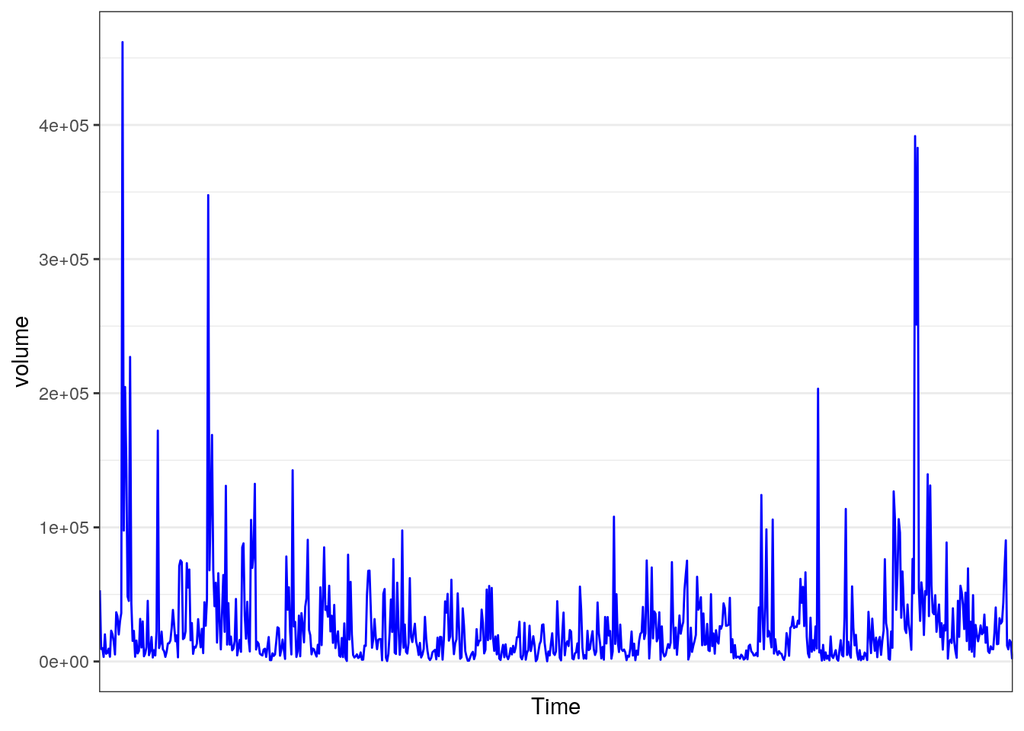

```r
ggplot(countinuous_phase_quarter_interval,
       aes(x = paste(date, interval), y = volume, group = 1)) +
  geom_line(colour = "blue") +
  theme_bw() +
  scale_x_discrete(name = "Time", breaks = 1)
```

```r
  labs(
    title = "Continuous phase volume by 15-min intervals",
    x = "Time",
    y = "Volume"
  )
```

```
## $x
## [1] "Time"
##
## $y
## [1] "Volume"
##
## $title
## [1] "Continuous phase volume by 15-min intervals"
##
## attr(,"class")
## [1] "labels"
```

## 2.c

### i

Algorytm wyznaczenia przedziału posiadającego najmniej sekund z transakcjami przebiega następująco: dla każdego przedziału (10:00-12:00, 11:00-13:00, …, 14:00-16:00), wyznacz minimalną liczbę sekund z transakcjami dla każdego dnia, wyznacz minimalny przedział z otrzymanych wyników

```r
compute_minimal_distinct_seconds_count <- function(hour_from, hour_to) {
  orange.df %>%
    filter(between(time, hour_from, hour_to)) %>%
    group_by(date) %>%
    summarise(distinct_seconds = n_distinct(time)) %>%
    ungroup() %>%
    filter(distinct_seconds == min(distinct_seconds)) %>%
    mutate(hour_from = hour_from, hour_to = hour_to)
}

minimal_interval_metadata <- bind_rows(
  compute_minimal_distinct_seconds_count(140000, 155959),
  compute_minimal_distinct_seconds_count(130000, 145959),
  compute_minimal_distinct_seconds_count(120000, 135959),
  compute_minimal_distinct_seconds_count(110000, 125959),
  compute_minimal_distinct_seconds_count(100000, 115959)
) %>%
  filter(distinct_seconds == min(distinct_seconds))
```

Modelowany rozkład ma dotyczyć każdej minuty z otrzymanego przedziału. Poniższy fragment kodu dokonuje preprocessingu tych danych przed modelowaniem.

```r
minimal_interval_data <- orange.df %>%
  filter(
    date == minimal_interval_metadata$date
    & between(time, minimal_interval_metadata$hour_from, minimal_interval_metadata$hour_to)
  ) %>%
  select(time) %>%
  distinct() %>%
  mutate(time = as.numeric(as.character(substr(time, 1, 4)))) %>%
  group_by(time) %>%
  summarise(seconds_count = n()) %>%
  add_row(time = 1100:1159, seconds_count = 0) %>%  # filling empty minutes
  add_row(time = 1200:1259, seconds_count = 0) %>%
  arrange(time, desc(seconds_count)) %>%
  group_by(time) %>%
  filter(row_number() == 1) %>% # remove fake 0 values for duplicated times
  ungroup() %>%
  mutate(time = 1:120)
```

Dwie funckcje pomocnicze zamieniają format daty i czasu na bardziej czytelny

```r
format_time <- function(raw_time) {
  return(formatC(as.integer(raw_time), big.mark = ":", big.interval = 2L))
}

format_date <- function(raw_date) {
  return(as.Date.character(raw_date, format = "%y%m%d"))
}
```

### Wykres sumy transakcji w każdej minucie dwugodzinnego przedziału

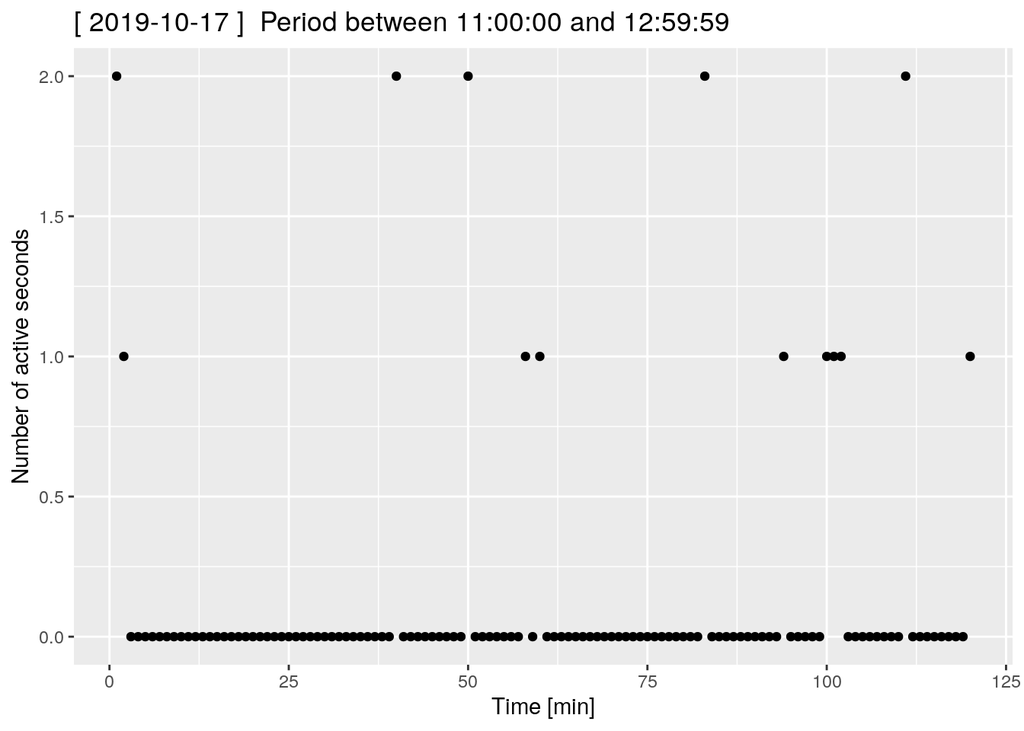

```r
ggplot(minimal_interval_data) +
  geom_point(aes(x = time, y = seconds_count)) +
  labs(
    title = paste("[", format_date(minimal_interval_metadata$date), "]", " Period between", format_time(minimal_interval_metadata$hour_from), "and", format_time(minimal_interval_metadata$hour_to)),
    x = "Time [min]",
    y = "Number of active seconds"
  )
```

### ii

Rozkład Poissona może być wyznaczony na podstawie średniej. W badanym przypadku wynosi 0.15.

```r
lambda <- mean(minimal_interval_data$seconds_count)
```

### iii

Zamodelowany rozkład jest zgodny z porównywanym zbiorem danych. W przypadku badanej spółki - Orange Polska S.A. liczba sekund, w których dokonano transakcji była nieznaczna, dlatego na wykresie znajdują się jedynie trzy słupki. Mimo to, rokład Poissona przedstawia zdecydowanie większe prawdopodobieństwo braku transakcji niż jednej oraz dwóch transakcji, co odpowiada danym, ponieważ w przedziale 120 minut sumaryczna liczba transakcji wynosiła zaledwie 18. Dodatkowo średnia liczba transakcji wynosi 0.15, czyli szansa na jakąkolwiek transakcję jest stosunkowo niewielka.

### Wykres porównujący rozkład modelowy z danymi

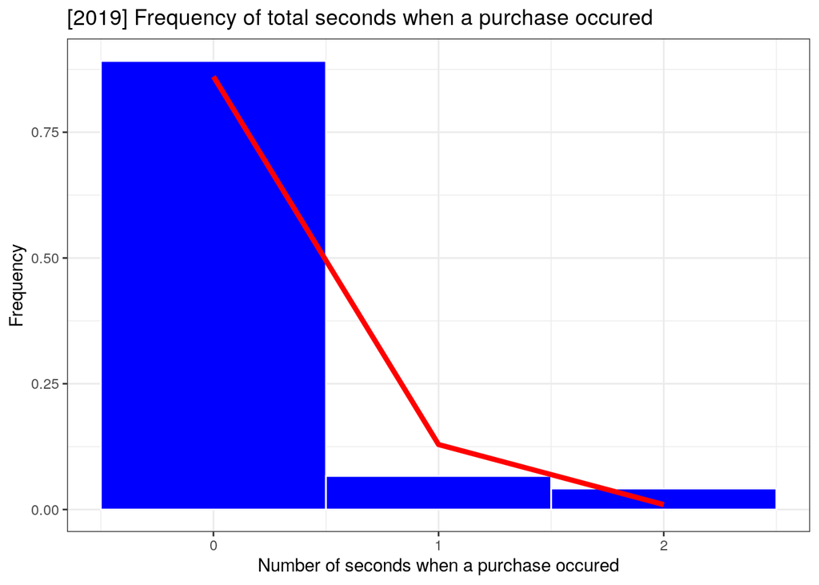

```r
draw_pois_histogram <- function(df) {
  ggplot(df, aes(seconds_count)) +
    theme_bw() +
    #scale_x_continuous(breaks=c(0,1,2,3,4)) +
    geom_histogram(aes(y = ..density.. ), colour="white", fill="blue", binwidth=1) +
    labs(
      title = paste("[2019] Frequency of total seconds when a purchase occured"),
      x = "Number of seconds when a purchase occured",
      y = "Frequency"
    )
}

draw_pois_histogram(minimal_interval_data) +
  stat_function(geom="line", n=3, fun=dpois, args=list(lambda=lambda), colour = "red", size=1.5)
```